# Project 2: Data Mining, Classification, Prediction

SDS322E

# Mining, Classification, Prediction

## Sara Blanco, seb4296

### Introduction

Throughout this project I used the candy_rankings dataset found in the fivethirtyeight package. I found this data by exploring the preloaded R datasets and was immediately intrigued by the thought of classifying candy! Halloween is my favorite holday, so I was very excited to be able to apply this data to the concepts we’ve explored throughout this course.

This dataset was initially used to rank Halloween candy and contains the name (competitorname), types and features of the candy (including chocolate, fruity, caramel, peanutyalmondy, nougat, crispedricewafer, hard, bar, and pluribus), and the percentages (sugarpercent, pricepercent, winpercent) for each candy. The variables measure whether or not each candy contains features (chocolate, nougat, etc.) and also the percentile of sugar and price along with the overall “win percentage” as determined by a matchup study. There are 85 observations and the values of True and False for each binary variable are listed below.

```r
library(tidyverse)
library(fivethirtyeight)
candy_rankings
```

```
## # A tibble: 85 x 13
##    competitorname chocolate fruity caramel peanutyalmondy nougat
##    <chr>          <lgl>     <lgl>  <lgl>   <lgl>          <lgl>
##  1 100 Grand      TRUE      FALSE  TRUE    FALSE          FALSE
##  2 3 Musketeers   TRUE      FALSE  FALSE   FALSE          TRUE
##  3 One dime       FALSE     FALSE  FALSE   FALSE          FALSE
##  4 One quarter    FALSE     FALSE  FALSE   FALSE          FALSE
##  5 Air Heads      FALSE     TRUE   FALSE   FALSE          FALSE
##  6 Almond Joy     TRUE      FALSE  FALSE   TRUE           FALSE
##  7 Baby Ruth      TRUE      FALSE  TRUE    TRUE           TRUE
##  8 Boston Baked … FALSE     FALSE  FALSE   TRUE           FALSE
##  9 Candy Corn     FALSE     FALSE  FALSE   FALSE          FALSE
## 10 Caramel Apple… FALSE     TRUE   TRUE    FALSE          FALSE
## # … with 75 more rows, and 7 more variables: crispedricewafer <lgl>,
## #   hard <lgl>, bar <lgl>, pluribus <lgl>, sugarpercent <dbl>,
## #   pricepercent <dbl>, winpercent <dbl>
```

```r
candy_rankings %>% select(chocolate, fruity, caramel, peanutyalmondy,
    nougat, crispedricewafer, hard, bar, pluribus) %>% sapply(table)
```

```
##       chocolate fruity caramel peanutyalmondy nougat crispedricewafer hard bar
## FALSE        48     47      71             71     78               78   70  64
## TRUE         37     38      14             14      7                7   15  21
##       pluribus
## FALSE       41
## TRUE        44
```

### Cluster Analysis

```r
library(cluster)

# Process data
clust_dat <- candy_rankings %>% dplyr::select(sugarpercent, pricepercent,
    winpercent)

# PAM
pam1 <- clust_dat %>% pam(k = 3)
pam1
```

```
## Medoids:
##      ID sugarpercent pricepercent winpercent
## [1,] 48        0.593        0.651   69.48379
## [2,] 51        0.581        0.116   37.34852
## [3,] 32        0.267        0.279   52.91139
## Clustering vector:
##  [1] 1 1 2 3 3 3 3 2 2 2 2 2 2 2 2 2 2 3 3 2 3 2 3 1 3 3 2 3 1 2 2 3 1 1 3 3 1 3
## [39] 1 3 3 3 1 1 2 2 3 1 2 2 2 1 1 1 1 2 1 2 2 2 1 3 2 3 1 3 3 3 1 2 2 2 2 3 3 2
## [77] 3 3 3 1 3 2 2 2 3
## Objective function:
##    build     swap
## 4.738810 4.629565
##
## Available components:
##  [1] "medoids"    "id.med"     "clustering" "objective"  "isolation"
##  [6] "clusinfo"   "silinfo"    "diss"       "call"       "data"
```

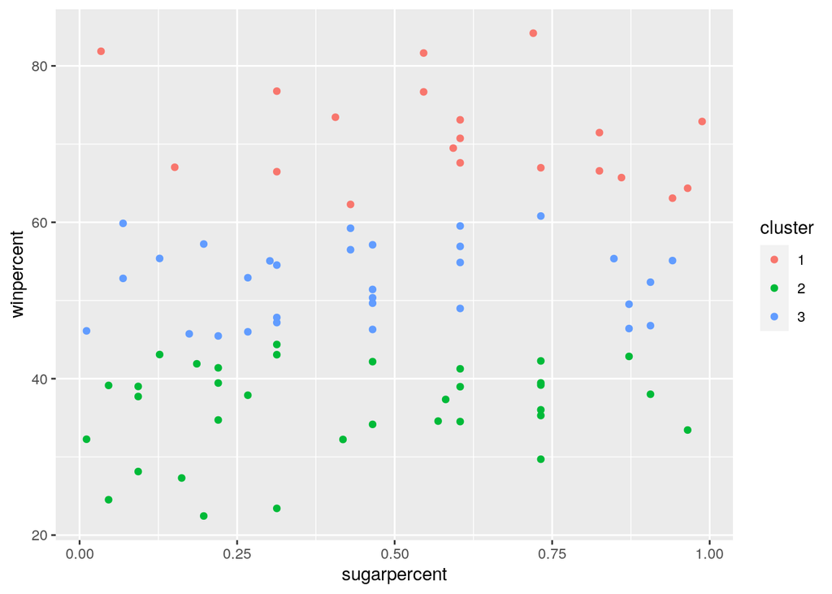

```r
# Visualize
pamclust <- clust_dat %>% mutate(cluster = as.factor(pam1$clustering))
pamclust %>% ggplot(aes(sugarpercent, winpercent, color = cluster)) +
    geom_point()
```

```r
# Summarize clusters
pamclust %>% group_by(cluster) %>% summarize_if(is.numeric, mean,
    na.rm = T)
```

```
## # A tibble: 3 x 4
##   cluster sugarpercent pricepercent winpercent
##   <fct>          <dbl>        <dbl>      <dbl>
## 1 1              0.600        0.644       71.1
## 2 2              0.422        0.362       36.2
## 3 3              0.462        0.473       52.4
```

```r
# Final medoids
candy_rankings %>% slice(pam1$id.med)
```

```
## # A tibble: 3 x 13
##   competitorname chocolate fruity caramel peanutyalmondy nougat crispedricewafer
##   <chr>          <lgl>     <lgl>  <lgl>   <lgl>          <lgl>  <lgl>
## 1 Peanut M&Ms    TRUE      FALSE  FALSE   TRUE           FALSE  FALSE
## 2 Red vines      FALSE     TRUE   FALSE   FALSE          FALSE  FALSE
## 3 Lifesavers bi… FALSE     TRUE   FALSE   FALSE          FALSE  FALSE
## # … with 6 more variables: hard <lgl>, bar <lgl>, pluribus <lgl>,
## #   sugarpercent <dbl>, pricepercent <dbl>, winpercent <dbl>
```

```r
# Average silhouette width
pam1$silinfo$avg.width
```

```
## [1] 0.552286
```

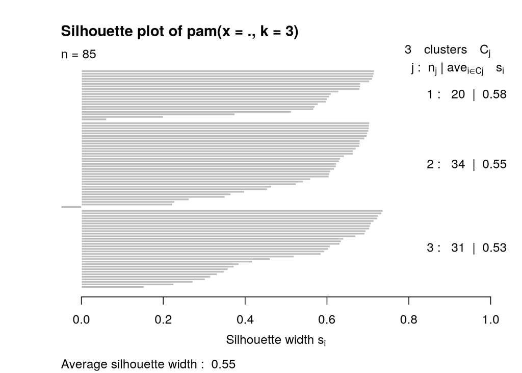

```r
plot(pam1, which = 2)
```

When initially performing clustering, I used three variables (sugarpercent, pricepercent, and winpercent) and a k value of 3 to perform PAM. The datapoints were then assigned to one of the three clusters and summarized to give the means for each of the three variables. I also pulled out the medoids for each cluster to show which candies were most representative in each group. PAM clustering classified this data with 0.552 accuracy represented in average silhouette width, which can be quantified as a reasonable structure.

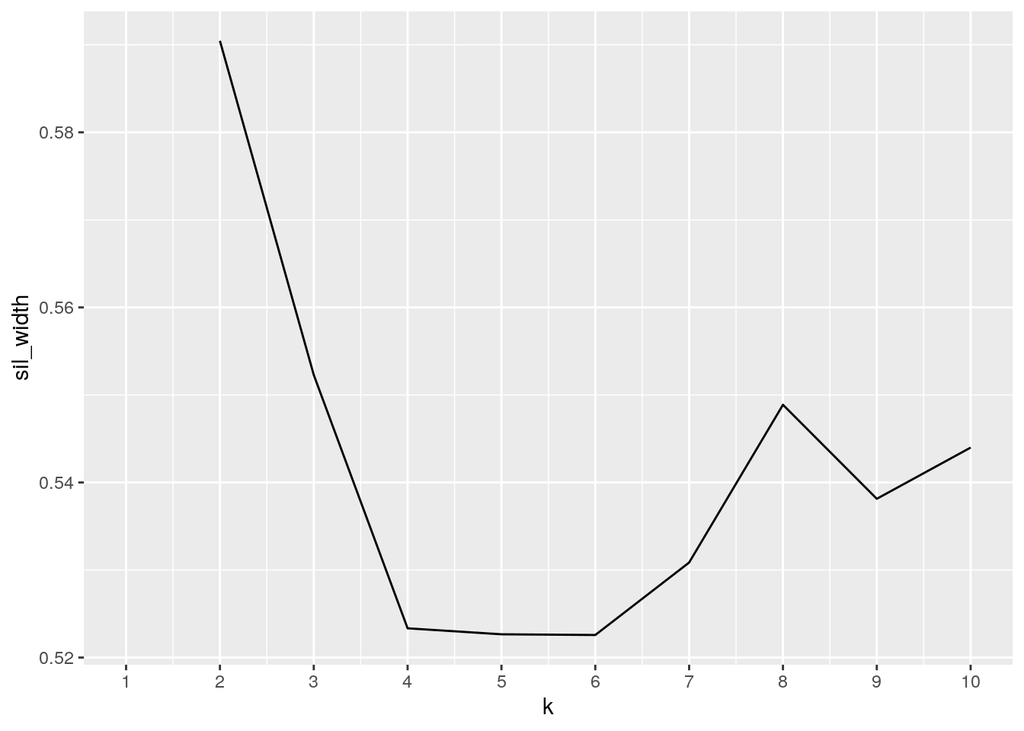

```r
# Picking number of clusters
pam_dat <- candy_rankings %>% select(sugarpercent, pricepercent,
    winpercent)
sil_width <- vector()
for (i in 2:10) {
    pam_fit <- pam(pam_dat, k = i)
    sil_width[i] <- pam_fit$silinfo$avg.width
}
ggplot() + geom_line(aes(x = 1:10, y = sil_width)) + scale_x_continuous(name = "k",
    breaks = 1:10)
```

```r
# PAM
pam2 <- clust_dat %>% pam(k = 2)
pam2
```

```
## Medoids:
##      ID sugarpercent pricepercent winpercent
## [1,] 57         0.86        0.860   65.71629
## [2,] 30         0.22        0.116   41.38956
## Clustering vector:
##  [1] 1 1 2 2 2 2 1 2 2 2 2 2 2 2 2 2 2 2 1 2 2 2 1 1 1 1 2 1 1 2 2 2 1 1 2 1 1 1
## [39] 1 2 1 1 1 1 2 2 2 1 2 2 2 1 1 1 1 2 1 2 2 2 1 1 2 2 1 1 1 2 1 2 2 2 2 1 2 2
## [77] 2 2 2 1 2 2 2 2 2
## Objective function:
##    build     swap
## 8.015574 6.670529
##
## Available components:
##  [1] "medoids"    "id.med"     "clustering" "objective"  "isolation"
##  [6] "clusinfo"   "silinfo"    "diss"       "call"       "data"
```

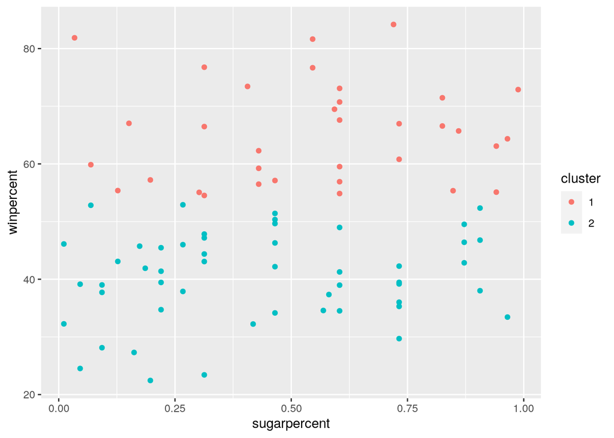

```r
# Visualize
pamclust2 <- clust_dat %>% mutate(cluster = as.factor(pam2$clustering))
pamclust2 %>% ggplot(aes(sugarpercent, winpercent, color = cluster)) +
    geom_point()
```

```r
# Summarize clusters
pamclust2 %>% group_by(cluster) %>% summarize_if(is.numeric,
    mean, na.rm = T)
```

```
## # A tibble: 2 x 4
##   cluster sugarpercent pricepercent winpercent
##   <fct>          <dbl>        <dbl>      <dbl>
## 1 1              0.549        0.603       65.3
## 2 2              0.432        0.380       40.3
```

```r
# Final medoids
candy_rankings %>% slice(pam2$id.med)
```

```
## # A tibble: 2 x 13
##   competitorname chocolate fruity caramel peanutyalmondy nougat crispedricewafer
##   <chr>          <lgl>     <lgl>  <lgl>   <lgl>          <lgl>  <lgl>
## 1 Rolo           TRUE      FALSE  TRUE    FALSE          FALSE  FALSE
## 2 Laffy Taffy    FALSE     TRUE   FALSE   FALSE          FALSE  FALSE
## # … with 6 more variables: hard <lgl>, bar <lgl>, pluribus <lgl>,
## #   sugarpercent <dbl>, pricepercent <dbl>, winpercent <dbl>
```

```r
# Average silhouette width/goodness of fit
pam2$silinfo$avg.width
```

```
## [1] 0.59045
```

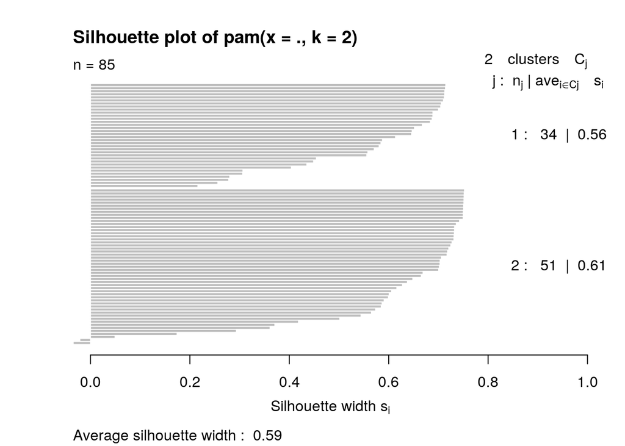

```r
plot(pam2, which = 2)
```

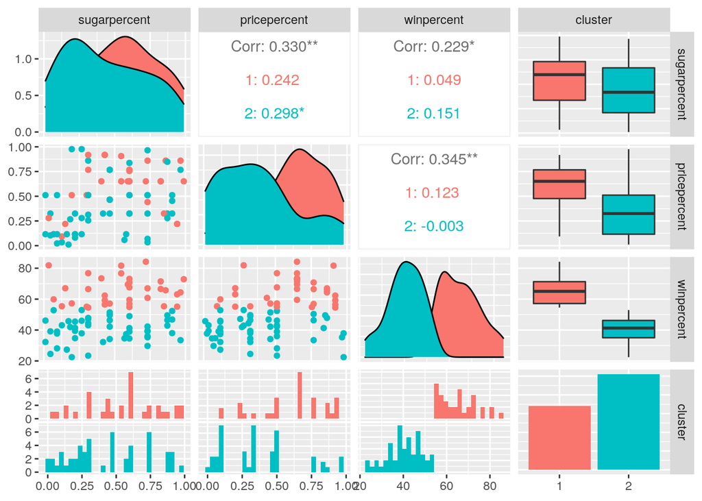

```r
# ggpairs
library(GGally)
ggpairs(pamclust2, columns = 1:4, aes(color = cluster))
```

At this point, we used a plot to find the largest silhouette width, which turned out to be 2, and applied this to our data. As a note, I attempted to scale the data, but this severely altered the strength of the structure, so I opted to skip this step. This model increased the average silhouette width to 0.590, which is still reasonable and slightly stronger! According to ggpairs, it appears that cluster 1 has a higher sugarpercent, high pricepercent, and high winpercent. Cluster 2 appears to have a low sugarpercent, lower pricepercent, and low winpercent.

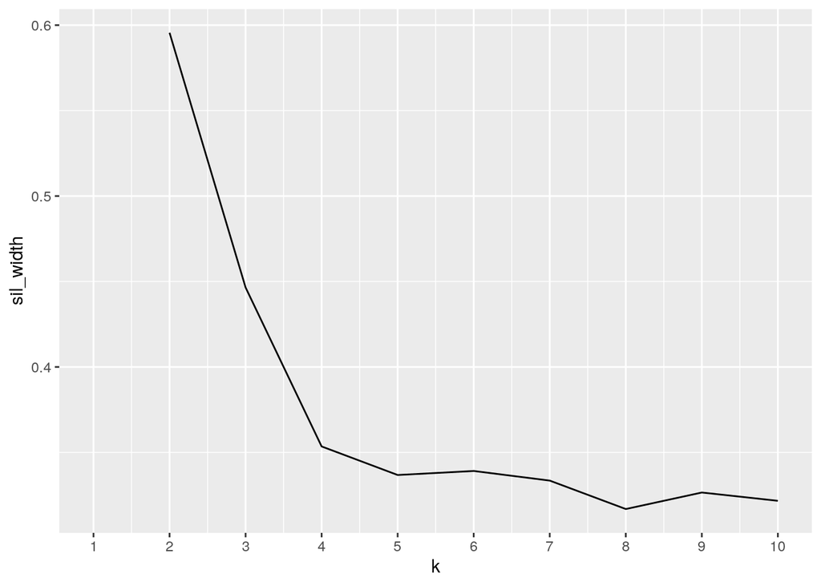

```r
# Incorporate categorical variable: gower
dat1 <- candy_rankings %>% mutate_if(is.logical, as.factor) %>%
    column_to_rownames("competitorname") %>% select(-fruity,
    -caramel, -peanutyalmondy, -nougat, -crispedricewafer, -hard,
    -bar, -pluribus)

gower1 <- daisy(dat1, metric = "gower")


# Number of clusters
sil_width <- vector()
for (i in 2:10) {
    pam_fit <- pam(gower1, diss = TRUE, k = i)
    sil_width[i] <- pam_fit$silinfo$avg.width
}
ggplot() + geom_line(aes(x = 1:10, y = sil_width)) + scale_x_continuous(name = "k",
    breaks = 1:10)
```

```r
# PAM
pam3 <- pam(gower1, k = 2, diss = T)
pam3
```

```
## Medoids:
##      ID
## [1,] "66" "Snickers Crisper"
## [2,] "83" "Welch's Fruit Snacks"
## Clustering vector:
##                   100 Grand                3 Musketeers
##                           1                           1
##                    One dime                 One quarter
##                           2                           2
##                   Air Heads                  Almond Joy
##                           2                           1
##                   Baby Ruth          Boston Baked Beans
##                           1                           2
##                  Candy Corn          Caramel Apple Pops
##                           2                           2
##             Charleston Chew  Chewey Lemonhead Fruit Mix
##                           1                           2
##                    Chiclets                        Dots
##                           2                           2
##                    Dum Dums                 Fruit Chews
##                           2                           2
##                     Fun Dip                  Gobstopper
##                           2                           2
##           Haribo Gold Bears           Haribo Happy Cola
##                           2                           2
##           Haribo Sour Bears          Haribo Twin Snakes
##                           2                           2
##            Hershey's Kisses           Hershey's Krackel
##                           1                           1
##    Hershey's Milk Chocolate      Hershey's Special Dark
##                           1                           1
##                  Jawbusters                Junior Mints
##                           2                           1
##                     Kit Kat                 Laffy Taffy
##                           1                           2
##                   Lemonhead Lifesavers big ring gummies
##                           2                           2
##         Peanut butter M&M's                       M&M's
##                           1                           1
##                  Mike & Ike                   Milk Duds
```

[output cut: 43 more lines]

```
##           Trolli Sour Bites                        Twix
##                           2                           1
##                   Twizzlers                    Warheads
##                           2                           2
##        Welch's Fruit Snacks  Werther's Original Caramel
##                           2                           2
##                    Whoppers
##                           1
## Objective function:
##     build      swap
## 0.1618962 0.1500504
##
## Available components:
## [1] "medoids"    "id.med"     "clustering" "objective"  "isolation"
## [6] "clusinfo"   "silinfo"    "diss"       "call"
```

```r
# Summary Statistics
dat1 %>% mutate(cluster = pam3$clustering) %>% group_by(cluster) %>%
    rename_all(function(x) str_replace(x, "_", "")) %>% summarize_if(is.numeric,
    .funs = list(mean = mean, median = median, sd = sd), na.rm = T) %>%
    pivot_longer(contains("_")) %>% separate(name, sep = "_",
    into = c("variable", "stat")) %>% pivot_wider(names_from = "variable",
    values_from = "value") %>% arrange(stat)
```

```
## # A tibble: 6 x 5
##   cluster stat   sugarpercent pricepercent winpercent
##     <int> <chr>         <dbl>        <dbl>      <dbl>
## 1       1 mean          0.512        0.632       60.9
## 2       2 mean          0.453        0.343       42.1
## 3       1 median        0.546        0.651       60.8
## 4       2 median        0.465        0.325       41.6
## 5       1 sd            0.242        0.251       12.8
## 6       2 sd            0.311        0.246       10.2
```

```r
# Medoids: most representative of their cluster
candy_rankings %>% slice(pam3$id.med)
```

```
## # A tibble: 2 x 13
##   competitorname chocolate fruity caramel peanutyalmondy nougat crispedricewafer
##   <chr>          <lgl>     <lgl>  <lgl>   <lgl>          <lgl>  <lgl>
## 1 Snickers Cris… TRUE      FALSE  TRUE    TRUE           FALSE  TRUE
## 2 Welch's Fruit… FALSE     TRUE   FALSE   FALSE          FALSE  FALSE
## # … with 6 more variables: hard <lgl>, bar <lgl>, pluribus <lgl>,
## #   sugarpercent <dbl>, pricepercent <dbl>, winpercent <dbl>
```

```r
# Interpreting fit/average silhouette width
pam3$silinfo$avg.width
```

```
## [1] 0.5955503
```

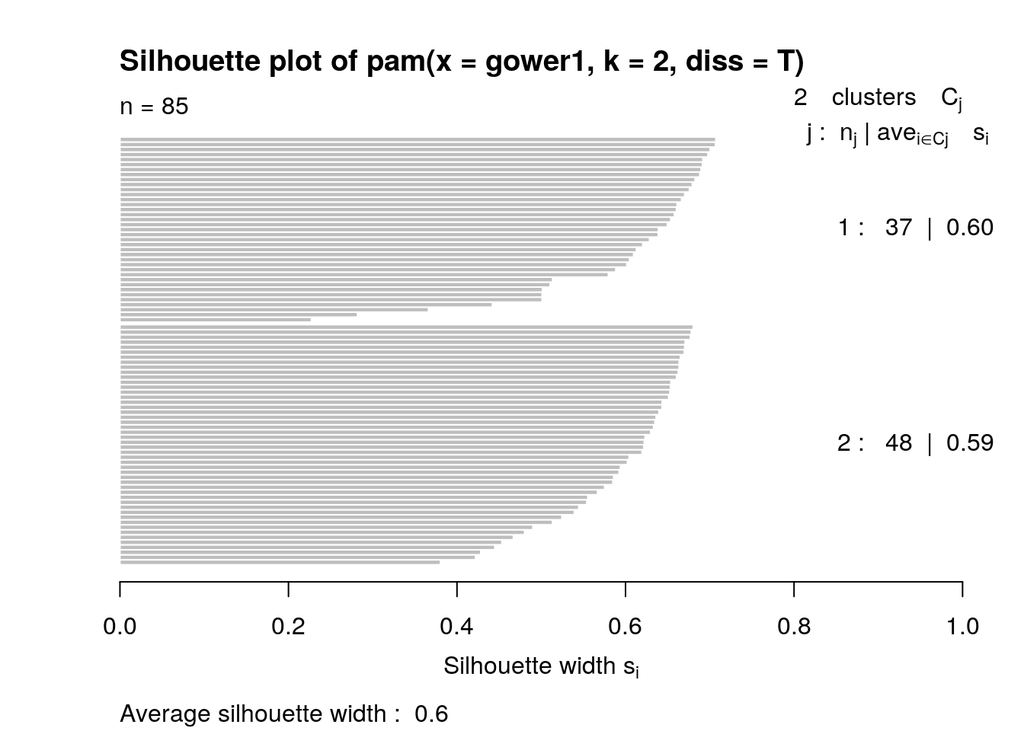

```r
plot(pam3, which = 2)
```

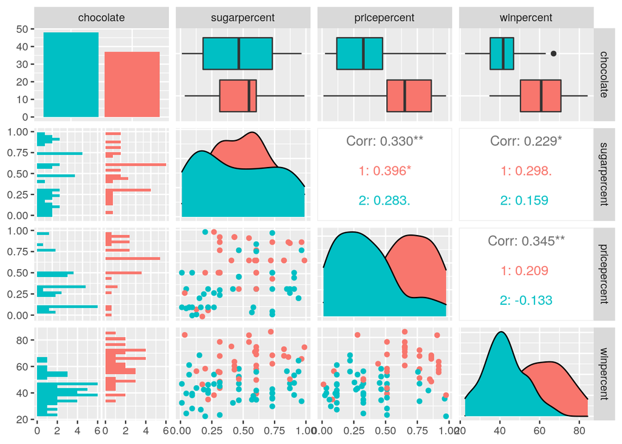

```r
# Visualizing: ggpairs
library(GGally)
ggpairs(dat1, columns = 1:4, aes(color = as.factor(pam3$clustering)))
```

### Dimensionality Reduction with PCA

```r
candy_p <- candy_rankings %>% select(competitorname, sugarpercent,
    pricepercent, winpercent)
candy <- candy_p %>% select_if(is.numeric) %>% scale
rownames(candy) <- candy_rankings$competitorname
candy_pca <- princomp(candy)
names(candy_pca)
```

```
## [1] "sdev"     "loadings" "center"   "scale"    "n.obs"    "scores"   "call"
```

```r
candy_pca
```

```
## Call:
## princomp(x = candy)
##
## Standard deviations:
##    Comp.1    Comp.2    Comp.3
## 1.2596116 0.8730571 0.7847648
##
##  3  variables and  85 observations.
```

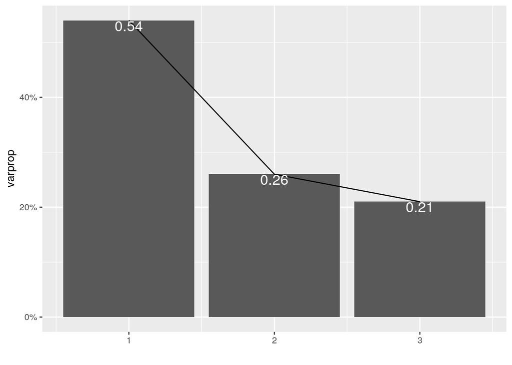

```r
# Chossing number of PCs
eigval <- candy_pca$sdev^2
varprop = round(eigval/sum(eigval), 2)

ggplot() + geom_bar(aes(y = varprop, x = 1:3), stat = "identity") +
    xlab("") + geom_path(aes(y = varprop, x = 1:3)) + geom_text(aes(x = 1:3,
    y = varprop, label = round(varprop, 2)), vjust = 1, col = "white",
    size = 5) + scale_y_continuous(breaks = seq(0, 0.6, 0.2),
    labels = scales::percent) + scale_x_continuous(breaks = 1:10)
```

```r
summary(candy_pca, loadings = T)
```

```
## Importance of components:
##                           Comp.1    Comp.2    Comp.3
## Standard deviation     1.2596116 0.8730571 0.7847648
## Proportion of Variance 0.5351699 0.2571010 0.2077292
## Cumulative Proportion  0.5351699 0.7922708 1.0000000
##
## Loadings:
##              Comp.1 Comp.2 Comp.3
## sugarpercent  0.549  0.736  0.395
## pricepercent  0.619        -0.784
## winpercent    0.561 -0.676  0.478
```

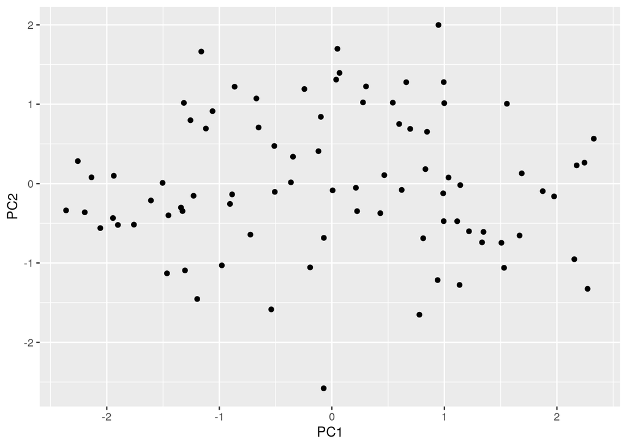

```r
candydf <- data.frame(Name = candy_rankings$competitorname, PC1 = candy_pca$scores[,
    1], PC2 = candy_pca$scores[, 2])

ggplot(candydf, aes(PC1, PC2)) + geom_point()
```

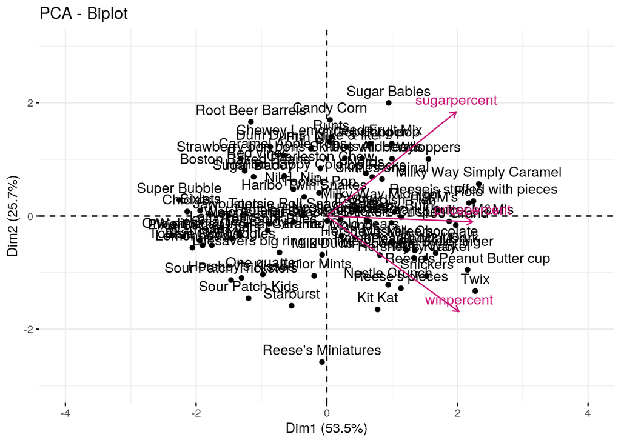

```r
library(factoextra)
fviz_pca_biplot(candy_pca, col.var = "deeppink3") + xlim(-4,
    4) + ylim(-3, 3)
```

Based on the plot of variance, I chose to keep the first two Principal Components. PC1 appears to be a general factor to assess the general goodness. All of the events within this component are positive, so a high score here means the candy is generally well liked, whereas a low score means the candy does poorer in each category. PC2 looks like it focuses on sugarpercent vs. winpercent. A higher score here means more sugar and a lower win percentage whereas a lower score may mean a higher win percentage and lower sugar percent. These two PCs account for 80% of the total variance in this dataset as seen in the plot. I chose to incorporate a biplot as a visual to show the candies included in our dataset and where they fall. You can see that names of candies like “Root Beer Barrels” and “Sour Patch Kids” which fall lower on Dimension 1 whereas the chocolate candies like “Kit Kat” and “Twix” are higher on this measure.

### Linear Classifier

```r
y_hat <- sample(c("TRUE", "FALSE"), size = length(candy_rankings$chocolate),
    replace = T)
candy_rankings %>% select(competitorname, chocolate, sugarpercent,
    pricepercent, winpercent) %>% mutate(prediction = y_hat)
```

```
## # A tibble: 85 x 6
##    competitorname     chocolate sugarpercent pricepercent winpercent prediction
##    <chr>              <lgl>            <dbl>        <dbl>      <dbl> <chr>
##  1 100 Grand          TRUE             0.732        0.860       67.0 FALSE
##  2 3 Musketeers       TRUE             0.604        0.511       67.6 FALSE
##  3 One dime           FALSE            0.011        0.116       32.3 TRUE
##  4 One quarter        FALSE            0.011        0.511       46.1 FALSE
##  5 Air Heads          FALSE            0.906        0.511       52.3 TRUE
##  6 Almond Joy         TRUE             0.465        0.767       50.3 TRUE
##  7 Baby Ruth          TRUE             0.604        0.767       56.9 FALSE
##  8 Boston Baked Beans FALSE            0.313        0.511       23.4 FALSE
##  9 Candy Corn         FALSE            0.906        0.325       38.0 FALSE
## 10 Caramel Apple Pops FALSE            0.604        0.325       34.5 FALSE
## # … with 75 more rows
```

```r
candy_rankings$chocolateIn <- as.integer(candy_rankings$chocolate)
fit <- glm(chocolateIn ~ sugarpercent + pricepercent + winpercent,
    data = candy_rankings, family = "binomial")
score <- predict(fit, type = "response")
# predictions for all observations
score %>% round(3)
```

```
##     1     2     3     4     5     6     7     8     9    10    11    12    13
## 0.951 0.860 0.033 0.524 0.326 0.709 0.817 0.032 0.033 0.036 0.128 0.073 0.028
##    14    15    16    17    18    19    20    21    22    23    24    25    26
## 0.151 0.016 0.075 0.052 0.155 0.624 0.077 0.441 0.191 0.340 0.959 0.916 0.940
##    27    28    29    30    31    32    33    34    35    36    37    38    39
## 0.083 0.769 0.972 0.072 0.070 0.387 0.924 0.866 0.098 0.675 0.958 0.598 0.900
##    40    41    42    43    44    45    46    47    48    49    50    51    52
## 0.774 0.913 0.267 0.964 0.963 0.201 0.126 0.590 0.935 0.039 0.438 0.023 0.977
##    53    54    55    56    57    58    59    60    61    62    63    64    65
## 0.987 0.971 0.916 0.326 0.929 0.005 0.053 0.027 0.351 0.161 0.624 0.114 0.976
##    66    67    68    69    70    71    72    73    74    75    76    77    78
## 0.794 0.531 0.311 0.793 0.013 0.098 0.038 0.013 0.764 0.199 0.299 0.087 0.258
##    79    80    81    82    83    84    85
## 0.199 0.996 0.116 0.067 0.180 0.142 0.594
```

```r
class_diag(score, truth = candy_rankings$chocolateIn, positive = 1)
```

```
##            acc   sens  spec    ppv     f1     ba    auc
## Metrics 0.8471 0.8108 0.875 0.8333 0.8219 0.8429 0.9105
```

```r
table(truth = factor(candy_rankings$chocolateIn == 1, levels = c("TRUE",
    "FALSE")), predictions = factor(score > 0.5, levels = c("TRUE",
    "FALSE")))
```

```
##        predictions
## truth   TRUE FALSE
##   TRUE    30     7
##   FALSE    6    42
```

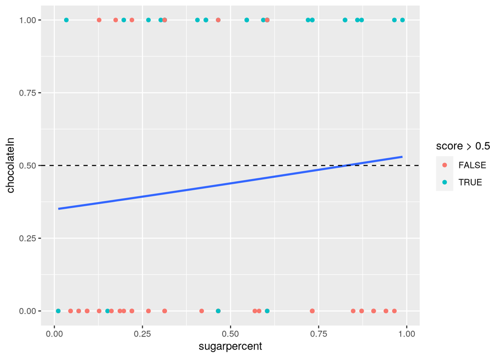

```r
candy_rankings %>% ggplot(aes(sugarpercent, chocolateIn)) + geom_point(aes(color = score >
    0.5)) + geom_smooth(method = "glm", se = F, method.args = list(family = "binomial")) +
    ylim(0, 1) + geom_hline(yintercept = 0.5, lty = 2)
```

```r
# cross-validation of linear classifier K-fold CV

k = 10
data <- candy_rankings[sample(nrow(candy_rankings)), ]
folds <- cut(seq(1:nrow(candy_rankings)), breaks = k, labels = F)

diags <- NULL
for (i in 1:k) {
    train <- data[folds != i, ]
    test <- data[folds == i, ]
    truth <- test$chocolateIn
    fit <- glm(chocolateIn ~ sugarpercent + pricepercent + winpercent,
        data = train, family = "binomial")
    probs <- predict(fit, newdata = test, type = "response")
    diags <- rbind(diags, class_diag(probs, truth, positive = 1))
}
summarize_all(diags, mean)
```

```
##       acc    sens    spec     ppv      f1      ba     auc
## 1 0.84862 0.79167 0.87643 0.81666 0.77709 0.83404 0.89888
```